# Topic 6: Regularization, shrinkage and dimension reduction

## Creating correlations

Generate points on circles of radius 1, 2, 3, …

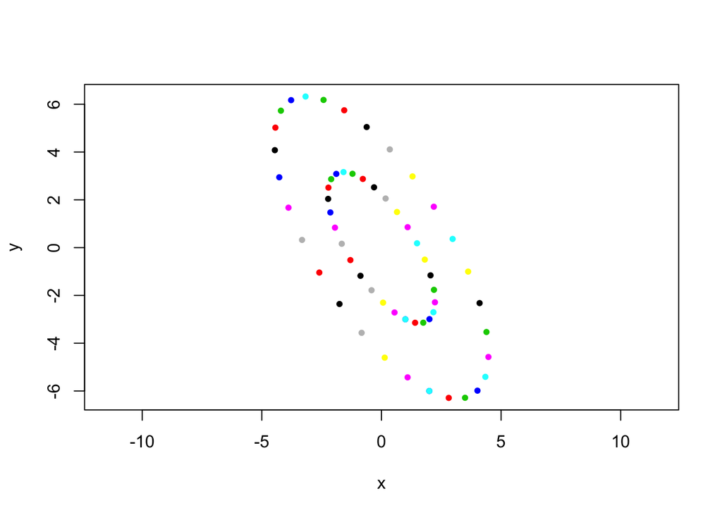

```r
make_circles <- function(radii = 1:2, nangs = 30) {
  theta = seq(0, 2*pi, length = nangs)
  x <- rep(cos(theta), length(radii))
  y <- rep(sin(theta), length(radii))
  r <- rep(radii, each = nangs)
  col <- rep(rainbow(nangs), length(radii))
  data.frame(x = x * r, y = y * r, r = r, col = col)
}
transform_circles <- function(M, circles = NULL) {
  if (is.null(circles)) circles <- make_circles()
  XY <- rbind(circles$x, circles$y)
  new <- M %*% XY
  circles$x = new[1, ]
  circles$y = new[2, ]

  circles
}



Trans <- matrix(c(1, 2, -3, -1), nrow = 2, byrow = TRUE)
After_trans <- transform_circles(Trans)
plot(y ~ x, data = After_trans, col = (After_trans$col), asp = 1, pch = 20)
```

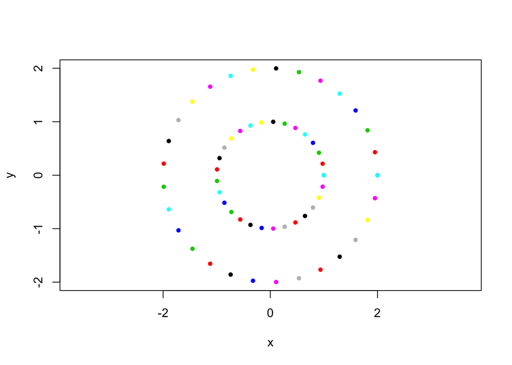

```r
svals <- svd(Trans)
Start <- make_circles()
plot(y ~ x, data = Start, col = Start$col, asp = 1, pch = 20)
```

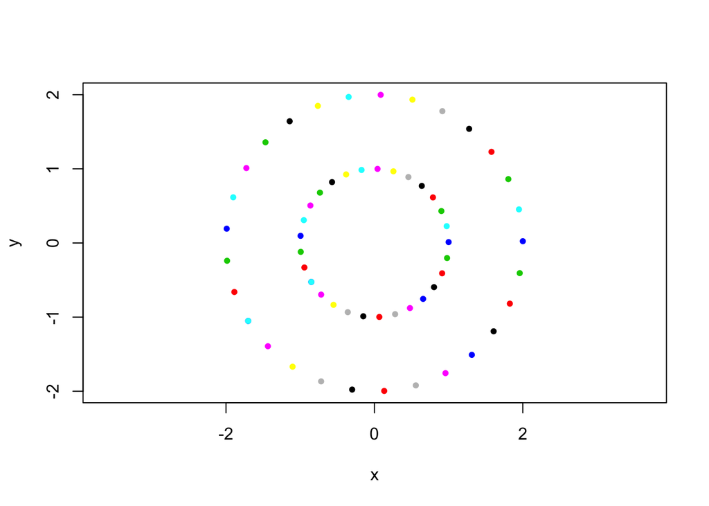

```r
After_V <- transform_circles(t(svals$v), Start)
plot(y ~ x, data = After_V, col = After_V$col, asp = 1, pch = 20)
```

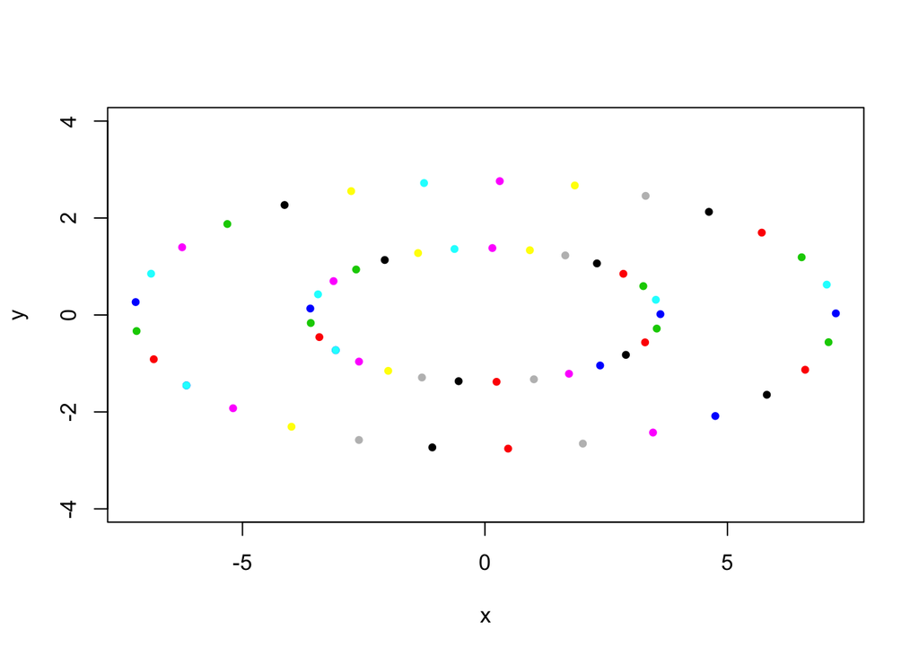

```r
After_V_lambda <- transform_circles(diag(svals$d), After_V)
plot(y ~ x, data <- After_V_lambda, col = After_V_lambda$col, asp = 1, pch = 20)
```

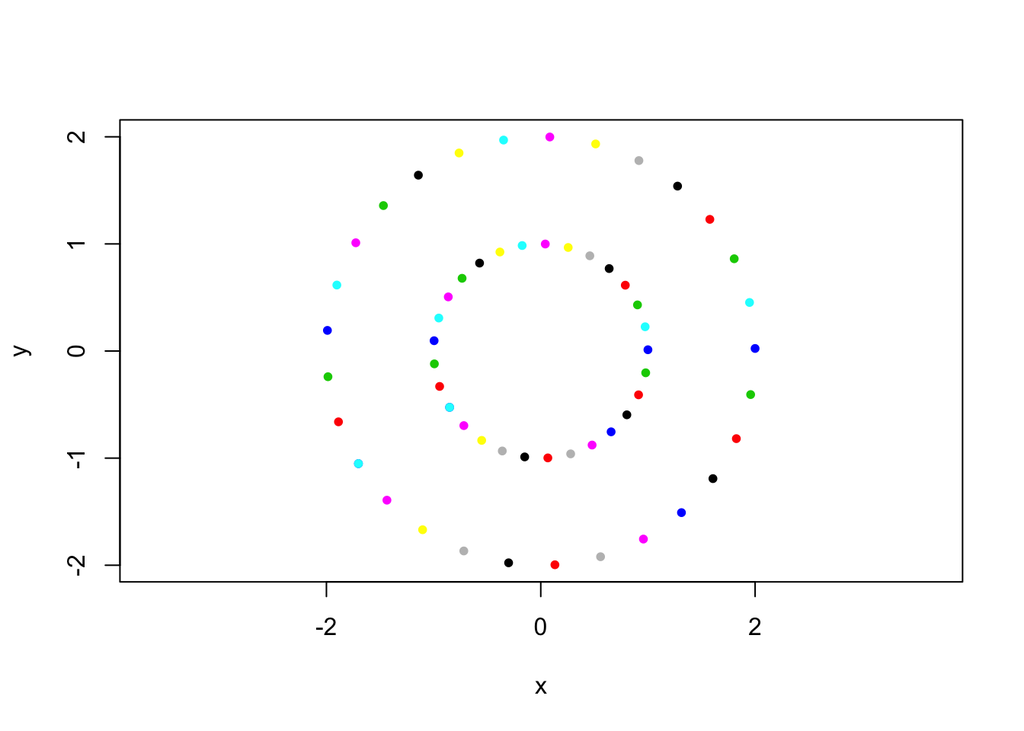

```r
After_V_lambda_U <- transform_circles(svals$u, After_V_lambda)
plot(y ~ x, data = After_V, col = After_V_lambda_U$col, asp = 1, pch = 20)
```

## Rank 1 Matrices

```r
set.seed(101)
one <- outer(rnorm(100), rnorm(10))
two <- outer(rnorm(100), rnorm(10))
three <- outer(rnorm(100), rnorm(10))
y <- rnorm(100) + 7 * one[, 1] - 2 * two[, 1]
x <- one + two

dim(one)
```

```
## [1] 100  10
```

```r
lm(y ~ x)
```

```
##
## Call:
## lm(formula = y ~ x)
##
## Coefficients:
## (Intercept)           x1           x2           x3           x4
##    -0.06554    -17.08557    -10.65980           NA           NA
##          x5           x6           x7           x8           x9
##          NA           NA           NA           NA           NA
##         x10
##          NA
```

```r
lasso_mod <- cv.glmnet(x, y, alpha = 1)
lasso_mod$lambda.min
```

```
## [1] 0.02322399
```

```r
predict(lasso_mod, type="coefficients", s=lasso_mod$lambda.min)
```

```
## 11 x 1 sparse Matrix of class "dgCMatrix"
##                       1
## (Intercept) -0.06467677
## V1           .
## V2           .
## V3           .
## V4           .
## V5           .
## V6          -3.00961477
## V7           .
## V8           .
## V9          -2.19570742
## V10          .
```

```r
ridge_mod <- cv.glmnet(one, y, alpha = 0)
ridge_mod$lambda.min
```

```
## [1] 2.046288
```

```r
predict(ridge_mod, type="coefficients", s=ridge_mod$lambda.min)
```

```
## 11 x 1 sparse Matrix of class "dgCMatrix"
##                       1
## (Intercept)  0.12330285
## V1           0.52231401
## V2          -0.23757058
## V3           0.06598347
## V4           0.11986807
## V5           0.18788200
## V6          -0.60749645
## V7           1.59250740
## V8          -0.06389472
## V9          -0.29849103
## V10          0.08247090
```

## Idea of singular values.

Find orthogonal vectors to describe the ellipsoidal cloud. The singular value describes “how long” each ellipsoidal axis is.

Correlation $R^2_{x_j | x_{-j}}$ gets increased for each *direction* that overlaps between $x_j$ and $x_{-j}$ — it doesn’t matter how big the singular value is in that direction. Only by throwing out *directions* can we reduce $R^2_{x_j | x_{-j}}$

Nice illustration:

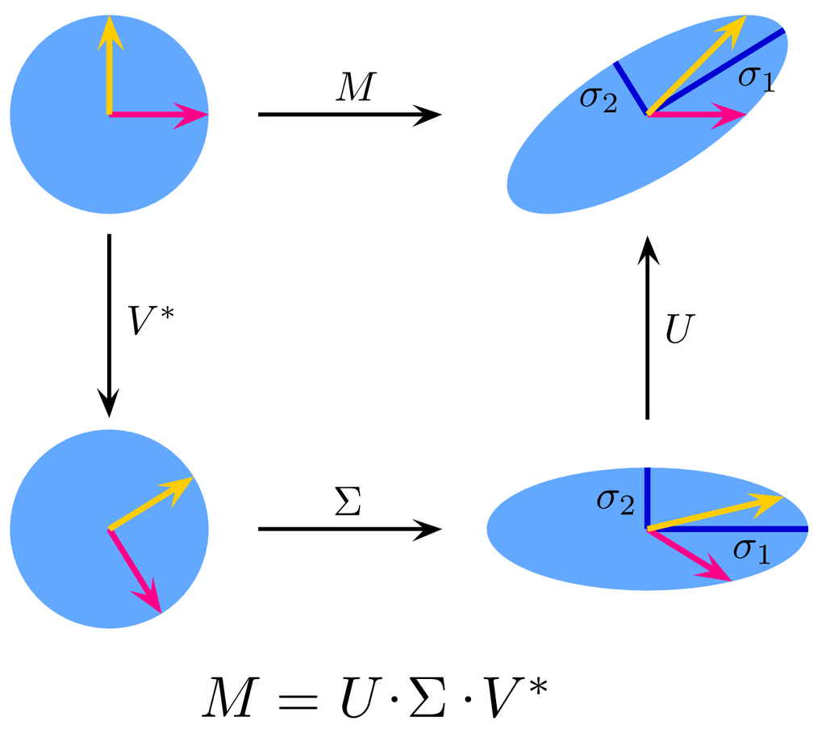

[Source](https://en.wikipedia.org/wiki/Singular_value_decomposition#/media/File:Singular-Value-Decomposition.svg)

## Dimension reduction

Re-arrange the variables to squeeze the juice out of them.

1. Matrix
2. Approximate matrix in a least squares sense. If that approximation includes the same column or more, we can discard the repeats.
3. Outer product
4. Rank-1 matrix constructed by creating multiples of one column.
5. Create another vector and another rank-1 matrix. Add it up and we get closer to the target.

Creating those singular vectors:

- singular value decomposition
- ${\mathbf D}$ gives information on how big they are
- orthogonal to one another
- cumulative sum of ${\mathbf D}$ components gives the amount of variance in the approximation.

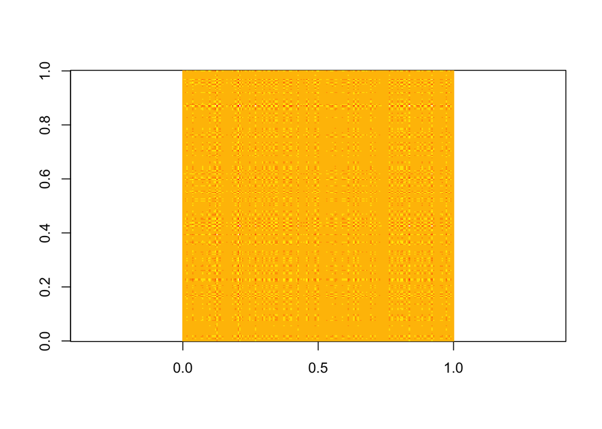

```r
load("images/mona.rda")
res <- svd(mona)
approx <- 0
for (i in 100) {
  approx <- approx + outer(res$u[,i], res$v[,i]) * res$d[i]
}
image(approx, asp=1)
```

Picture in terms of gaussian cloud. The covariance matrix tells all that you need.

Using `pcr()` to fit models, interpreting the output.

```r
library(pls)
pcr.fit <- pcr(Salary ~ ., data = ISLR::Hitters, scale=TRUE, validation="CV")
summary(pcr.fit)
```

```
## Data:    X dimension: 263 19
##  Y dimension: 263 1
## Fit method: svdpc
## Number of components considered: 19
##
## VALIDATION: RMSEP
## Cross-validated using 10 random segments.
##        (Intercept)  1 comps  2 comps  3 comps  4 comps  5 comps  6 comps
## CV             452    354.3    353.2    353.7    351.6    348.7    345.2
## adjCV          452    353.9    352.7    353.1    350.9    348.0    344.3
##        7 comps  8 comps  9 comps  10 comps  11 comps  12 comps  13 comps
## CV       345.8    349.3    351.5     357.6     358.9     361.6     362.3
## adjCV    344.9    348.2    350.3     356.0     357.1     359.8     360.4
##        14 comps  15 comps  16 comps  17 comps  18 comps  19 comps
## CV        355.4       355     346.7     346.4     346.0     349.4
## adjCV     353.3       353     344.6     344.3     343.7     346.9
##
## TRAINING: % variance explained
##         1 comps  2 comps  3 comps  4 comps  5 comps  6 comps  7 comps
## X         38.31    60.16    70.84    79.03    84.29    88.63    92.26
## Salary    40.63    41.58    42.17    43.22    44.90    46.48    46.69
##         8 comps  9 comps  10 comps  11 comps  12 comps  13 comps  14 comps
## X         94.96    96.28     97.26     97.98     98.65     99.15     99.47
## Salary    46.75    46.86     47.76     47.82     47.85     48.10     50.40
##         15 comps  16 comps  17 comps  18 comps  19 comps
## X          99.75     99.89     99.97     99.99    100.00
## Salary     50.55     53.01     53.85     54.61     54.61
```

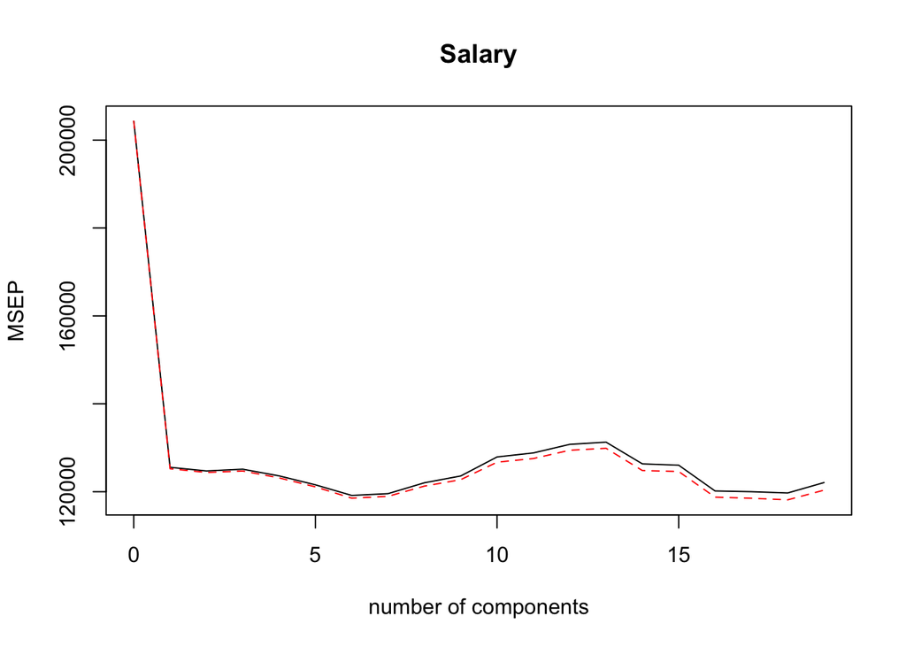

```r
validationplot(pcr.fit, val.type = "MSEP")
```